# Regression model VII : Model selection

related chapter : 10

For all but the simplest cases we are confronted with a choice of possible regression models for our data.

- The smallest model that fits the data adequately is best.
- Unnecessary predictors will add noise to the estimation of other quantities that interested us.

When comparing potential models, we might use hypothesis testing methods to make a choice or use some criterion-based method on the relative fit to decide.

# 1 Testing-Based Procedures

## 1.1 Backward Elimination

We start with all the predictors in the model and then remove the predictor with highest p-value greater than $\alpha_0$ . Next refit the model and remove the remaining least significant predictor provided its p-value is greater than $\alpha_0$ . Sooner or later, all “nonsignificant” predictors will be removed and the selection process will be complete.

## 1.2 Forward Selection

We start with no variables in the model and then for all predictors not in the model, we check their p-values if they are added to the model. We choose the one with lowest p-value less than $\alpha_0$ . We continue until no new predictors can be added.

## 1.3 Stepwise Selection

Combination of backward elimination and forward selection. This addresses the situation where variables are added or removed early in the process and we want to change our mind about them later. At each stage a variable may be added or removed and there are several variations on exactly how this is done.

> Backward Example

```r
library(faraway)
data(state)
statedata <- data.frame(state.x77,row.names=state.abb)
lmod <- lm(Life.Exp ~ ., statedata)
sumary(lmod)
```

```
##                Estimate  Std. Error t value  Pr(>|t|)
## (Intercept)  7.0943e+01  1.7480e+00 40.5859 < 2.2e-16
## Population   5.1800e-05  2.9187e-05  1.7748   0.08318
## Income      -2.1804e-05  2.4443e-04 -0.0892   0.92934
## Illiteracy   3.3820e-02  3.6628e-01  0.0923   0.92687
## Murder      -3.0112e-01  4.6621e-02 -6.4590  8.68e-08
## HS.Grad      4.8929e-02  2.3323e-02  2.0979   0.04197
## Frost       -5.7350e-03  3.1432e-03 -1.8246   0.07519
## Area        -7.3832e-08  1.6682e-06 -0.0443   0.96491
##
## n = 50, p = 8, Residual SE = 0.74478, R-Squared = 0.74
```

```r
lmod <- update(lmod, . ~ . - Area)
sumary(lmod)
```

```
##                Estimate  Std. Error t value  Pr(>|t|)
## (Intercept)  7.0989e+01  1.3875e+00 51.1652 < 2.2e-16
## Population   5.1883e-05  2.8788e-05  1.8023   0.07852
## Income      -2.4440e-05  2.3429e-04 -0.1043   0.91740
## Illiteracy   2.8459e-02  3.4163e-01  0.0833   0.93400
## Murder      -3.0182e-01  4.3344e-02 -6.9634 1.454e-08
## HS.Grad      4.8472e-02  2.0667e-02  2.3454   0.02369
## Frost       -5.7758e-03  2.9702e-03 -1.9446   0.05839
##
## n = 50, p = 7, Residual SE = 0.73608, R-Squared = 0.74
```

```r
lmod <- update(lmod, . ~ . - Illiteracy)
sumary(lmod)
```

```
##                Estimate  Std. Error t value  Pr(>|t|)
## (Intercept)  7.1066e+01  1.0289e+00 69.0669 < 2.2e-16
## Population   5.1149e-05  2.7095e-05  1.8878   0.06566
## Income      -2.4771e-05  2.3160e-04 -0.1070   0.91531
## Murder      -3.0001e-01  3.7042e-02 -8.0992 2.907e-10
## HS.Grad      4.7758e-02  1.8591e-02  2.5689   0.01367
## Frost       -5.9099e-03  2.4678e-03 -2.3948   0.02095
##
## n = 50, p = 6, Residual SE = 0.72773, R-Squared = 0.74
```

```r
lmod <- update(lmod, . ~ . - Income)
sumary(lmod)
```

```
##                Estimate  Std. Error t value  Pr(>|t|)
## (Intercept) 71.02712853  0.95285296 74.5415 < 2.2e-16
## Population   0.00005014  0.00002512  1.9960  0.052005
## Murder      -0.30014880  0.03660946 -8.1987 1.775e-10
## HS.Grad      0.04658225  0.01482706  3.1417  0.002968
## Frost       -0.00594329  0.00242087 -2.4550  0.018018
##
## n = 50, p = 5, Residual SE = 0.71969, R-Squared = 0.74
```

```r
lmod <- update(lmod, . ~ . - Population)
sumary(lmod)
```

```
##               Estimate Std. Error t value  Pr(>|t|)
## (Intercept) 71.0363788  0.9832622 72.2456 < 2.2e-16
## Murder      -0.2830652  0.0367313 -7.7064 8.039e-10
## HS.Grad      0.0499487  0.0152011  3.2859  0.001950
## Frost       -0.0069117  0.0024475 -2.8240  0.006988
##
## n = 50, p = 4, Residual SE = 0.74267, R-Squared = 0.71
```

```r
sumary(lm(Life.Exp ~ Illiteracy+Murder+Frost, statedata))
```

```
##               Estimate Std. Error  t value  Pr(>|t|)
## (Intercept) 74.5567171  0.5842507 127.6108 < 2.2e-16
## Illiteracy  -0.6017607  0.2989270  -2.0131  0.049981
## Murder      -0.2800474  0.0433940  -6.4536 6.033e-08
## Frost       -0.0086910  0.0029595  -2.9367  0.005166
##
## n = 50, p = 4, Residual SE = 0.79112, R-Squared = 0.67
```

Testing-based procedures are relatively cheap computationally and easy to understand, but they do have some drawbacks:

1. Because of the “one-at-a-time” nature of adding/dropping variables, it is possible to miss the “optimal” model.
2. The p-values used should not be treated too literally. There is so much multiple testing occurring that the validity is dubious. The removal of less significant predictors tends to increase the significance of the remaining predictors. This effect leads one to overstate the importance of the remaining predictors.
3. The procedures are not directly linked to final objectives of prediction or explanation and so may not really help solve the problem of interest.
4. Stepwise variable selection tends to pick models that are smaller than desirable for prediction purposes.

# 2 Criterion-Based Procedures

If we have some idea about the purpose for which a model is intended, we might propose some measure of how well a given model meets that purpose. We could choose that model among those possible that optimize that criterion.

## 2.1 AIC (Akaike Information Criterion)

Find a model that minimizes

$$AIC = -2 L(\hat\theta) + 2p$$
where $L(\hat\theta)$ is the maximized log-likelihood and $p$ is the number of parameters.

For linear regression models,

$$AIC = n\log(RSS/n) +constant + 2p$$

As adding more predictors into the model, the first term of AIC gets smaller and the second term becomes larger.

Hence, we see that AIC naturally provides a balance between fit and simplicity in model selection.

Another criteria have been proposed. For example,

$$BIC = -2 L(\hat\theta) + p\log n$$
which is called Bayesian Information Criteria. This includes other form of penalty for model complexity.

BIC penalizes larger models more heavily and so will tend to prefer smaller models in comparison to AIC and AIC is generally considered better when prediction is the aim.

```r
require(leaps)
b <- regsubsets(Life.Exp~.,data=statedata)
rs <- summary(b)
rs$which
```

```
##   (Intercept) Population Income Illiteracy Murder HS.Grad Frost  Area
## 1        TRUE      FALSE  FALSE      FALSE   TRUE   FALSE FALSE FALSE
## 2        TRUE      FALSE  FALSE      FALSE   TRUE    TRUE FALSE FALSE
## 3        TRUE      FALSE  FALSE      FALSE   TRUE    TRUE  TRUE FALSE
## 4        TRUE       TRUE  FALSE      FALSE   TRUE    TRUE  TRUE FALSE
## 5        TRUE       TRUE   TRUE      FALSE   TRUE    TRUE  TRUE FALSE
## 6        TRUE       TRUE   TRUE       TRUE   TRUE    TRUE  TRUE FALSE
## 7        TRUE       TRUE   TRUE       TRUE   TRUE    TRUE  TRUE  TRUE
```

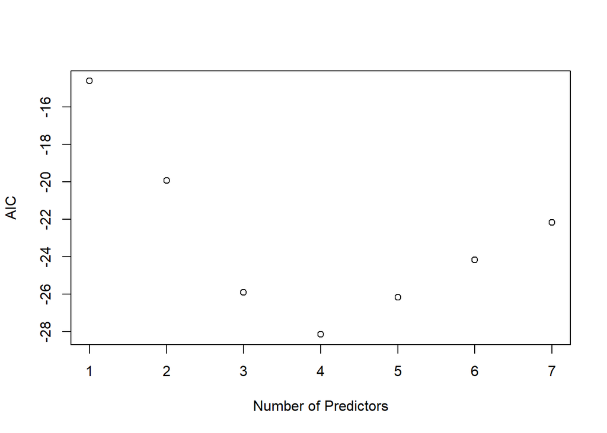

```r
AIC <- 50*log(rs$rss/50) + (2:8)*2
plot(AIC ~ I(1:7), ylab="AIC", xlab="Number of Predictors")
```

#### 2.1.0.1 Adjusted $R$ squares

$$R_a^2 = 1- \frac{RSS/(n-p-1)}{SST/(n-1)} = 1-\frac{n-1}{n-p-1}(1-R^2)$$
As all knows, $R^2$ is not useful for model selection since it always goes up as $p$ increases. $R_a^2$ is a modified verstion of $R^2$ for the purpose of model selection.

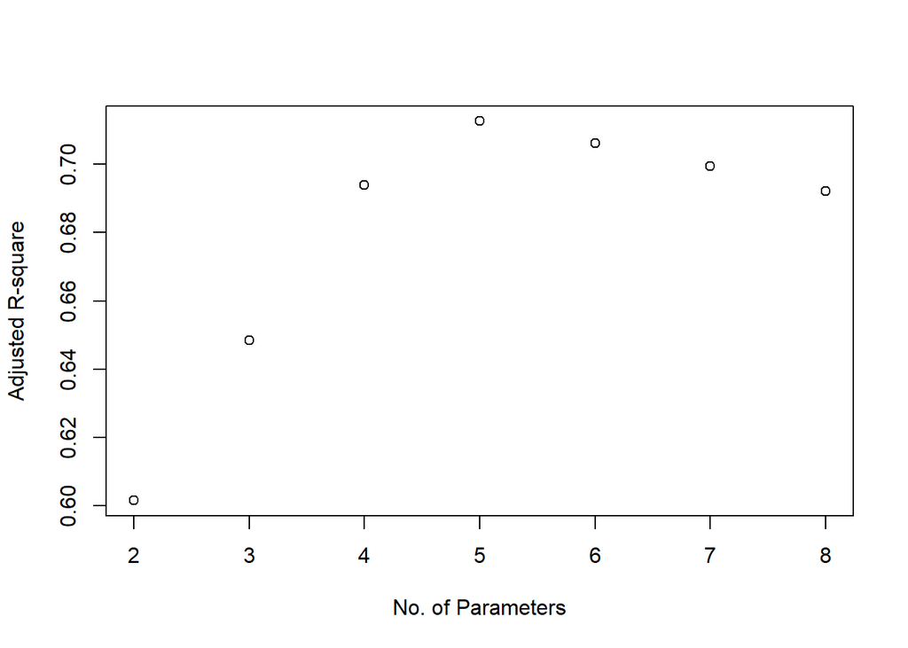

```r
plot(2:8,rs$adjr2,xlab="No. of Parameters",ylab="Adjusted R-square")
```

```r
which.max(rs$adjr2)
```

```
## [1] 4
```

#### 2.1.0.2 Mallow’s $C_p$ statistic

A good model should predict well, so the average mean square error of prediction might be a good criterion:

$$\frac{1}{\sigma^2} \sum_i E(\hat y_i - E y_i )^2$$
which can be estimated by

$$C_p = \frac{RSS_p}{\hat\sigma^2} + 2p-n$$
where $\hat\sigma^2$ comes from the full model and $RSS_p$ comes from the model with $p$-parameters. Since $E(RSS_p)=(n-p)\sigma^2$, $E(C_p) \approx p$ and a bad fit will results in $C_p >> p$. We desire models with small $p$ and $C_p$ around or less than $p$.

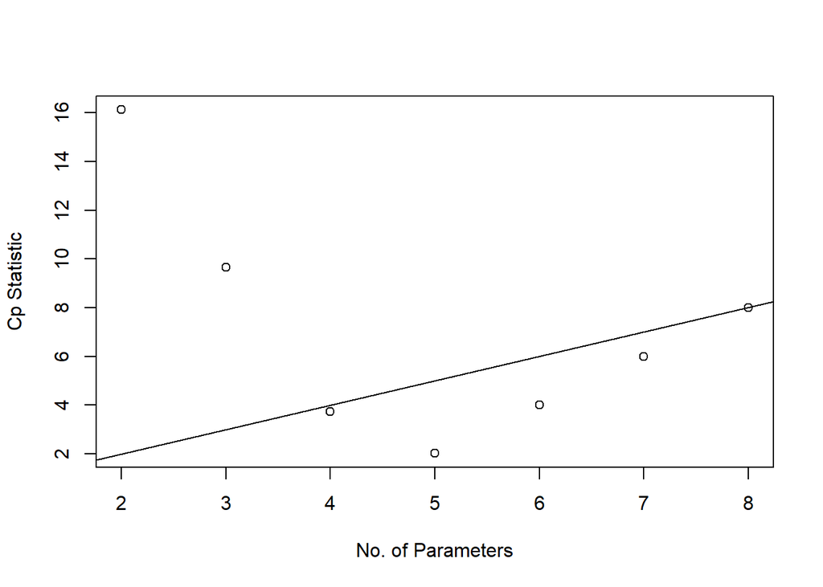

```r
plot(2:8,rs$cp,xlab="No. of Parameters",ylab="Cp Statistic")
abline(0,1)
```

If there are $q$ potential predictors, then there are $2^q$ possible models. For larger $q$, this might be too time consuming and we may need to economize by limiting the search. In such cases, the step() function is a cheaper alternative.

```r
lmod <- lm(Life.Exp ~ ., data=statedata)
step(lmod)
```

```
## Start:  AIC=-22.18
## Life.Exp ~ Population + Income + Illiteracy + Murder + HS.Grad +
##     Frost + Area
##
##              Df Sum of Sq    RSS     AIC
## - Area        1    0.0011 23.298 -24.182
## - Income      1    0.0044 23.302 -24.175
## - Illiteracy  1    0.0047 23.302 -24.174
## <none>                    23.297 -22.185
## - Population  1    1.7472 25.044 -20.569
## - Frost       1    1.8466 25.144 -20.371
## - HS.Grad     1    2.4413 25.738 -19.202
## - Murder      1   23.1411 46.438  10.305
##
## Step:  AIC=-24.18
## Life.Exp ~ Population + Income + Illiteracy + Murder + HS.Grad +
##     Frost
##
##              Df Sum of Sq    RSS     AIC
## - Illiteracy  1    0.0038 23.302 -26.174
## - Income      1    0.0059 23.304 -26.170
## <none>                    23.298 -24.182
## - Population  1    1.7599 25.058 -22.541
## - Frost       1    2.0488 25.347 -21.968
## - HS.Grad     1    2.9804 26.279 -20.163
## - Murder      1   26.2721 49.570  11.569
##
## Step:  AIC=-26.17
## Life.Exp ~ Population + Income + Murder + HS.Grad + Frost
##
##              Df Sum of Sq    RSS     AIC
## - Income      1     0.006 23.308 -28.161
## <none>                    23.302 -26.174
## - Population  1     1.887 25.189 -24.280
## - Frost       1     3.037 26.339 -22.048
## - HS.Grad     1     3.495 26.797 -21.187
## - Murder      1    34.739 58.041  17.456
##
## Step:  AIC=-28.16
## Life.Exp ~ Population + Murder + HS.Grad + Frost
##
##              Df Sum of Sq    RSS     AIC
## <none>                    23.308 -28.161
## - Population  1     2.064 25.372 -25.920
## - Frost       1     3.122 26.430 -23.877
## - HS.Grad     1     5.112 28.420 -20.246
## - Murder      1    34.816 58.124  15.528
```

```
##
## Call:
## lm(formula = Life.Exp ~ Population + Murder + HS.Grad + Frost,
##     data = statedata)
##
## Coefficients:
## (Intercept)   Population       Murder      HS.Grad        Frost
##   7.103e+01    5.014e-05   -3.001e-01    4.658e-02   -5.943e-03
```

# 3 Exercise

1. # 10.1
2. # 10.2